# Descrip_lutuk

Alfredo Acosta

2024-05-26

# 1 Survey Mapping ASF outbreak Lutuk March 2024

```r
# Library ----
library(readxl)
library(arsenal)
library(dplyr)
library(lubridate)
library(leaflet)
library(sf)
library(DT)
library(psych)
library(sjmisc)
```

```r
library(ggplot2)
```

## 1.1 Working directory

```r
setwd("C:/Users/alfredo.acosta/OneDrive - SVA/ASF_Uganda/R/")
```

## 1.2 Reading excel file

```r
l <- read_xlsx("Kopia av Lutuk_data collection on ASF outbreak 2024 MIRED May 6.xlsx", col_types = "text")
m <- read_xlsx("kopia av Lutuk_data collection on ASF outbreak 2024 MIRED May 6 GV.xlsx", col_types = "text")
```

# 2 Comparison between versions

```r
comparedf(l, m)
```

```
## Compare Object
##
## Function Call:
## comparedf(x = l, y = m)
##
## Shared: 60 non-by variables and 99 observations.
## Not shared: 0 variables and 0 observations.
##
## Differences found in 2/60 variables compared.
## 0 variables compared have non-identical attributes.
```

```r
summary(comparedf(l, m))
```

```
##
##
## Table: Summary of data.frames
##
## version   arg    ncol   nrow
## --------  ----  -----  -----
## x         l        60     99
## y         m        60     99
##
##
##
## Table: Summary of overall comparison
##
## statistic                                                      value
## ------------------------------------------------------------  ------
## Number of by-variables                                             0
## Number of non-by variables in common                              60
## Number of variables compared                                      60
## Number of variables in x but not y                                 0
## Number of variables in y but not x                                 0
## Number of variables compared with some values unequal              2
## Number of variables compared with all values equal                58
## Number of observations in common                                  99
## Number of observations in x but not y                              0
## Number of observations in y but not x                              0
## Number of observations with some compared variables unequal        9
## Number of observations with all compared variables equal          90
## Number of values unequal                                           9
##
##
##
## Table: Variables not shared
##
##
##  ------------------------
##  No variables not shared
##  ------------------------
##
##
##
```

[output cut: 92 more lines]

```
## Number in Gwen’s and Ana’s data collection   Number in Gwen’s and Ana’s data collection               82  NA               18                                                     82      82
## Number in Gwen’s and Ana’s data collection   Number in Gwen’s and Ana’s data collection               84  32               32 36                                                  84      84
## Number in Gwen’s and Ana’s data collection   Number in Gwen’s and Ana’s data collection               87  31               31 Not sure this is someone Gwen/Ana interviewed       87      87
## Name                                         Name                                                     76  Ajod Plavia      Ajod Plavia Ajok Flavia                                76      76
## Name                                         Name                                                     83  Aryema Stephen   Aryema Stephen Oryema Stephen                          83      83
## Name                                         Name                                                     92  Obina Michale    Obina Michale Obina Michael                            92      92
##
##
##
## Table: Non-identical attributes
##
##
##  ----------------------------
##  No non-identical attributes
##  ----------------------------
```

```r
# Differences detected in administration variables. deleting m
rm(m)
```

## 2.1 Colnames preparation

```r
colnames(l) <- c("1digited_by",
"l2_Way_point",
"l3_NGwenAna_col",
"l4_Sub_village",
"l5_Date_interview",
"l6_Name_producer",
"l7_Gender",
"l8_Age_years",
"l9_Norting",
"l10_Easting",
"l11_Interviewed_by_G&Ana",
"l12_first_detection_ill_pig",
"l13_first_pig_die",
"l14_N_init",
"l15_N_affected",
"l16_N_deaths",
"l17_N_interview",
"l18_pnd_slaughtered",#Pigsnot dead (pnd)
"l19_pnd_sold_alive",
"l20_pnd_kept",
"l21_pnd_other",
"l22_pnd_other(what)",
"l23_pd_Ate",
"l24_pd_Sold",
"l25_pd_buried",
"l26_pd_burned",
"l27_pd_latrine",
"l28_pd_bush_swamp_river",
"l29_pd_other",
"l30_pd_other_what",
"l31_Why_sick_Weather",
"l32_Why_Witchcraft",
"l33_Why_Poison",
"l34_Why_Jealousy",
"l35_Why_Someone_killed_it",
"l36_Why_pig_ate_something",
"l37_Why_infected_by_sick_pig",
"l38_Why_got_infected_by_a_person",
"l39_Why_Other",
"l40_Why_(reason_other)",
"l41_If_your_pig_was_infected_by_another_pig_or_person,how_this happened?",
"l42_What_do_Slaughtered",
"l43_What_do_Sold_alive",
"l44_What_do_Slaughtered_healthy_pig(s)",
"l45_What_do_Sold_healthy_pig",
"l46_What_Prayed_",
"l47_What_Separated_ill_from",
"l48_What_do_tied_my_pigs_fenced",
"l49_What_do_Gave_medication",
"l50_What_do_(what)",
"l51_What_do_asked_for_help",
"l52_What_do_asked_for_help(whom)",
"l53_What_do_Other_(yes/no)",
"l54_What_do_Other(what)",
"l55_How_this_affects_your_life?",
"l56_How_do_you_feel",
"l57_Do_you_think_invest_again",
"l58_Why_or_why_not?",
"l59_Is there anything you like to add?",
"l60_Kommentarer från den som fyller i Excel")
```

```r
colnames(l)
```

```
##  [1] "1digited_by"
##  [2] "l2_Way_point"
##  [3] "l3_NGwenAna_col"
##  [4] "l4_Sub_village"
##  [5] "l5_Date_interview"
##  [6] "l6_Name_producer"
##  [7] "l7_Gender"
##  [8] "l8_Age_years"
##  [9] "l9_Norting"
## [10] "l10_Easting"
## [11] "l11_Interviewed_by_G&Ana"
## [12] "l12_first_detection_ill_pig"
## [13] "l13_first_pig_die"
## [14] "l14_N_init"
## [15] "l15_N_affected"
```

[output cut: 45 more lines]

# 3 Date checking

## 3.1 Premises with death pigs but without date of first detection of ill pig

## 3.2 ? 66 and 116 excluded

```r
l$Date_first_detection_ill_pig <- dmy(l$l12_first_detection_ill_pig)
l$Date_first_pig_die <- dmy(l$l13_first_pig_die)
l$Date_interview <- dmy(l$l5_Date_interview)
# l %>%
#   select(l2_Way_point, l6_Name_producer,
#          Date_interview,
#          l12_first_detection_ill_pig,
#          Date_first_detection_ill_pig, l16_N_deaths) %>%
#   filter(is.na(Date_first_detection_ill_pig) & l16_N_deaths > 0)

#Correcting 66 from the form
l$Date_first_detection_ill_pig[l$l2_Way_point == 66] <- l$Date_interview[l$l2_Way_point == 66] - days(53)
l$Date_first_detection_ill_pig[l$l2_Way_point == 116] <- l$Date_interview[l$l2_Way_point == 116] - days(53)
```

## 3.3 Premises with death pigs but without date of first death of pig

## 3.4 ?? 37,38,40,42,43 I assume that date of first pig die will be the mean days between detection and die

## 3.5 6 outbreaks in 2023 and 46 in 2024 NA 47

## 3.6 Replacing 2023 to 2024 in first detection and death

## 3.7 31,37,46,49,72,79 replaced date of first detection in 2023 to 2024 interview date and death date matches

## 3.8 ?31 replaced date of death 2024 to 2023

```r
# l %>%
#   filter(year(Date_first_detection_ill_pig) == 2023) %>%
#   select(l2_Way_point,
#        l6_Name_producer,
#        Date_first_detection_ill_pig,
#        Date_interview,
#        Date_first_pig_die,
#        l16_N_deaths)

l <- l %>%
  mutate(Date_first_detection_ill_pig = as.Date(ifelse(lubridate::year(Date_first_detection_ill_pig) == 2023,
         Date_first_detection_ill_pig + lubridate::years(1),
         Date_first_detection_ill_pig)))

# l %>%
#   filter(year(Date_first_pig_die) == 2023) %>%
#   select(l2_Way_point,
#        l6_Name_producer,
#        Date_first_detection_ill_pig,
#        Date_interview,
#        Date_first_pig_die,
#        l16_N_deaths)

l <- l %>%
  mutate(Date_first_pig_die = as.Date(ifelse(lubridate::year(Date_first_pig_die) == 2023,
         Date_first_pig_die + lubridate::years(1),
         Date_first_pig_die)))

l <- l %>%
  mutate(Date_first_detection_ill_pig = as.Date(ifelse(lubridate::year(Date_first_detection_ill_pig) != 2024,
         Date_first_detection_ill_pig + lubridate::years(-1),
         Date_first_detection_ill_pig)))
```

## 3.9 Outbreaks with date of first_detection inoctober and december

```r
l %>%
  group_by(year(l$Date_first_detection_ill_pig),
           month(l$Date_first_detection_ill_pig, label=TRUE)) %>%
  summarise(n())
```

```
## can override using the `.groups` argument.
```

```
## # A tibble: 7 × 3
## # Groups:   year(l$Date_first_detection_ill_pig) [2]
##   `year(l$Date_first_detection_ill_pig)` month(l$Date_first_detection_il…¹ `n()`
##                                    <dbl> <ord>                             <int>
## 1                                   2024 feb                                  31
## 2                                   2024 mar                                  19
## 3                                   2024 apr                                   1
## 4                                   2024 maj                                   1
## 5                                   2024 okt                                   1
## 6                                   2024 dec                                   1
## 7                                     NA <NA>                                 45
## # ℹ abbreviated name: ¹`month(l$Date_first_detection_ill_pig, label = TRUE)`
```

```r
l %>%
  group_by(year(l$Date_first_pig_die),
           month(l$Date_first_pig_die, label=TRUE)) %>%
  summarise(n())
```

```
## # A tibble: 4 × 3
## # Groups:   year(l$Date_first_pig_die) [2]
##   `year(l$Date_first_pig_die)` `month(l$Date_first_pig_die, label = TRUE)` `n()`
##                          <dbl> <ord>                                       <int>
## 1                         2024 feb                                            10
## 2                         2024 mar                                            25
## 3                         2024 okt                                             1
## 4                           NA <NA>                                           63
```

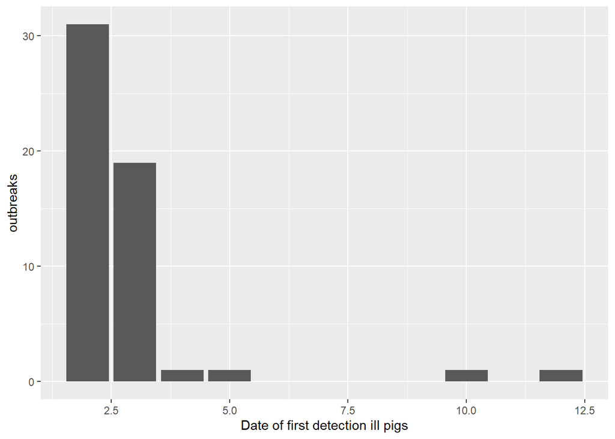

```r
l %>%
  group_by(Month=month(Date_first_detection_ill_pig)) %>%
  summarise(outbreaks=n()) %>%
  ggplot(aes(Month, outbreaks))+
  geom_col()+
  labs(x="Date of first detection ill pigs")
```

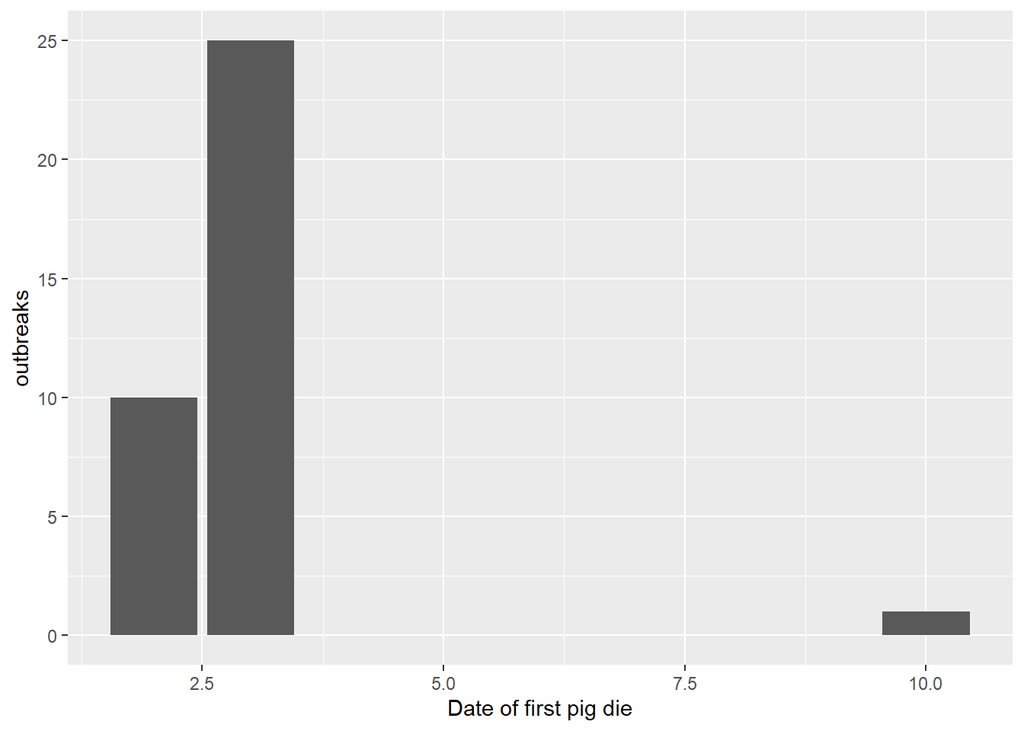

```r
l %>%
  group_by(Month=month(Date_first_pig_die)) %>%
  summarise(outbreaks=n()) %>%
  ggplot(aes(Month, outbreaks))+
  geom_col()+
  labs(x="Date of first pig die")
```

## Events in October and december, make sense?? ## form 98 corrected Date of interview from image

```r
# l %>%
# select(l2_Way_point,
#        l5_Date_interview,
#        Date_interview,
#        l6_Name_producer,
#        Date_first_detection_ill_pig,
#        Date_first_pig_die,
#        l16_N_deaths) %>%
#   filter(month(Date_first_detection_ill_pig) >5)

#Correcting 98 from the form
l$Date_interview[l$l2_Way_point == 98] <- as.Date("2024-03-27")

#Correcting 67 and 98 from 2024 to 2023
l <- l %>%
  mutate(Date_first_detection_ill_pig = as.Date(ifelse(lubridate::month(Date_first_detection_ill_pig) > 5,
         Date_first_detection_ill_pig + lubridate::years(-1),
         Date_first_detection_ill_pig)))


# l %>%
# select(l2_Way_point,
#        l5_Date_interview,
#        Date_interview,
#        l6_Name_producer,
#        Date_first_detection_ill_pig,
#        Date_first_pig_die,
#        l16_N_deaths) %>%
#   filter(month(Date_first_pig_die) >5)


l <- l %>%
  mutate(Date_first_pig_die = as.Date(ifelse(lubridate::month(Date_first_pig_die) > 5,
         Date_first_pig_die + lubridate::years(-1),
         Date_first_pig_die)))
```

# 4 Visualization of months

## 4.1 Time differences

## 4.2 101, 40 thefirst detection of ill pigs happens after the interview (7 and 1 days), check the dates.

## 4.3 35 first pig die before detecting the disease. The problem is incorrect transcript first detection 3 or 5 march, first pig die on 7 of march and the interview was on 15 of march. Corrected.

```r
l$dif_first_detection_to_interview <- l$Date_interview - l$Date_first_detection_ill_pig

l$dif_first_pig_die_to_interview <- l$Date_interview - l$Date_first_pig_die

summary(as.numeric(l$dif_first_detection_to_interview))
```

```
##    Min. 1st Qu.  Median    Mean 3rd Qu.    Max.    NA's
##  -51.00   16.00   23.00   26.83   34.00  169.00      46
```

```r
summary(as.numeric(l$dif_first_detection_to_interview))
```

```
##    Min. 1st Qu.  Median    Mean 3rd Qu.    Max.    NA's
##  -51.00   16.00   23.00   26.83   34.00  169.00      46
```

```r
summary(as.numeric(l$dif_first_pig_die_to_interview))
```

```
##    Min. 1st Qu.  Median    Mean 3rd Qu.    Max.    NA's
##   -2.00   13.00   19.00   25.09   26.00  168.00      64
```

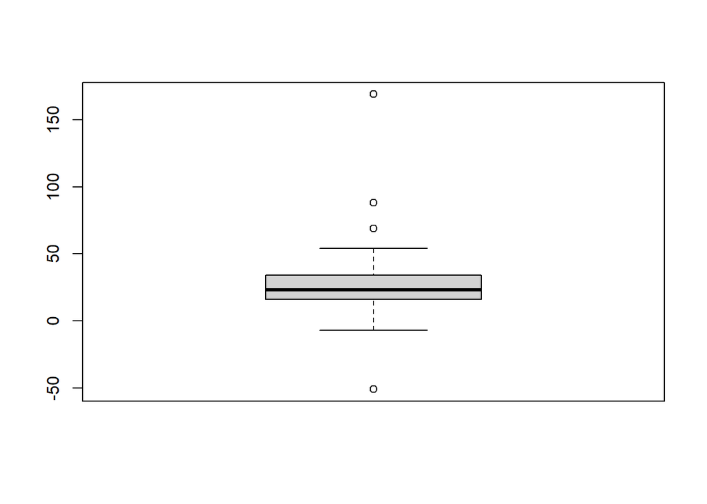

```r
boxplot(as.numeric(l$dif_first_detection_to_interview))
```

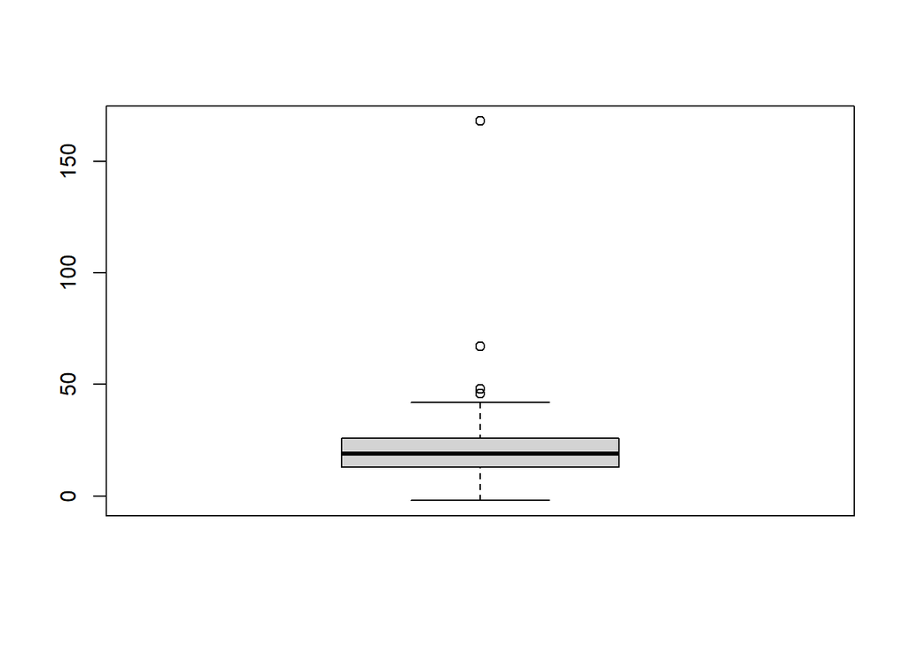

```r
boxplot(as.numeric(l$dif_first_pig_die_to_interview))
```

```r
l$l16_N_deaths <- as.numeric(l$l16_N_deaths)
summary(as.numeric(l$Date_interview - l$Date_first_detection_ill_pig))
```

```
##    Min. 1st Qu.  Median    Mean 3rd Qu.    Max.    NA's
##  -51.00   16.00   23.00   26.83   34.00  169.00      46
```

```r
l %>%
  group_by(l4_Sub_village) %>%
  summarise(n(), mean(dif_first_detection_to_interview, na.rm = TRUE))
```

```
## # A tibble: 13 × 3
##    l4_Sub_village `n()` `mean(dif_first_detection_to_interview, na.rm = TRUE)`
##    <chr>          <int> <drtn>
##  1 Aeoka A            7 55.000000 days
##  2 Aeoka B           13 23.000000 days
##  3 Aeoka C           13 16.000000 days
##  4 Ayeka Yeka         9  9.857143 days
##  5 Bargonja A         2       NaN days
##  6 Bargonja B         6 62.666667 days
##  7 Gogo               3 25.500000 days
##  8 Kamcoo             1 19.000000 days
##  9 Lacen Otingo       1       NaN days
## 10 Lamina Too         1       NaN days
## 11 Lutuk A           20 23.230769 days
## 12 Lutuk B           15 29.800000 days
## 13 Obaka oo           8 22.000000 days
```

```r
# l %>%
#   group_by(l2_Way_point,
#           l6_Name_producer,
#            Date_first_detection_ill_pig,
#            Date_first_pig_die,
#            Date_interview,
#            dif_first_detection_to_interview) %>%
#   filter(dif_first_detection_to_interview <0) %>%
#   summarise(n())

#Correcting 35 from the form
l$Date_first_detection_ill_pig[l$l2_Way_point == 35] <- as.Date("2024-03-05")
```

## 4.4 Time difference between detection and death

## 4.5 116

```r
l$dif_detection_death <- l$Date_first_pig_die - l$Date_first_detection_ill_pig

summary(as.numeric(l$dif_detection_death))
```

```
##    Min. 1st Qu.  Median    Mean 3rd Qu.    Max.    NA's
## -19.000   1.000   2.000   2.972   3.000  32.000      63
```

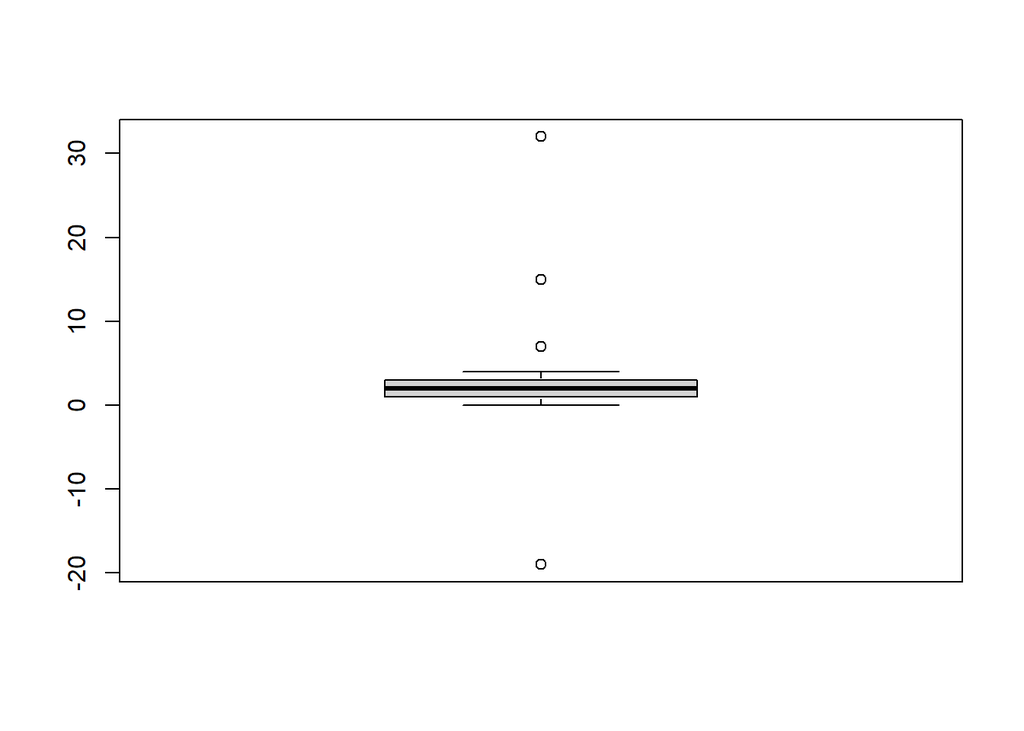

```r
boxplot(as.numeric(l$dif_detection_death))
```

```r
# l %>%
#   group_by(l2_Way_point,
#           l6_Name_producer,
#            Date_first_detection_ill_pig,
#            Date_first_pig_die,
#            Date_interview,
#            dif_first_detection_to_interview,
#             dif_detection_death) %>%
#   filter(l16_N_deaths >0) %>%
#   summarise(n()) %>%
#   arrange(desc(dif_detection_death))

# Corrected 80
l$Date_first_pig_die[l$l2_Way_point == 80] <- as.Date("2024-02-29")
```

## 4.7 Selection of cases=1, controls=0

```r
l %>%
  group_by(l2_Way_point,
           Date_first_detection_ill_pig,
           Date_first_pig_die,
           Date_interview,
           dif_first_detection_to_interview,
          dif_detection_death) %>%
  filter(l16_N_deaths >0) %>%
  filter(!is.na(Date_first_detection_ill_pig)) %>%
  summarise(n()) %>%
  arrange(desc(dif_detection_death))
```

```
## 'Date_first_detection_ill_pig', 'Date_first_pig_die', 'Date_interview',
## 'dif_first_detection_to_interview'. You can override using the `.groups`
## argument.
```

```
## # A tibble: 42 × 7
## # Groups:   l2_Way_point, Date_first_detection_ill_pig, Date_first_pig_die,
## #   Date_interview, dif_first_detection_to_interview [42]
##    l2_Way_point Date_first_detection_ill_pig Date_first_pig_die Date_interview
##    <chr>        <date>                       <date>             <date>
##  1 44           2024-02-11                   2024-03-14         2024-03-19
##  2 61           2024-02-27                   2024-03-05         2024-03-22
##  3 64           2024-02-20                   2024-02-27         2024-03-23
##  4 125          2024-03-01                   2024-03-05         2024-04-10
##  5 62           2024-02-27                   2024-03-02         2024-03-23
##  6 63           2024-02-29                   2024-03-04         2024-03-23
##  7 68           2024-03-01                   2024-03-05         2024-03-27
##  8 120          2024-03-11                   2024-03-14         2024-04-06
##  9 34           2024-02-28                   2024-03-02         2024-03-15
## 10 41           2024-03-15                   2024-03-18         2024-03-16
## # ℹ 32 more rows
## # ℹ 3 more variables: dif_first_detection_to_interview <drtn>,
## #   dif_detection_death <drtn>, `n()` <int>
```

```r
l <- l %>%
  mutate(cases = ifelse(!is.na(Date_first_detection_ill_pig) & l16_N_deaths > 0, "Case", "Control"))

table(l$cases)
```

```
##
##    Case Control
##      42      57
```

```r
# l %>%
#   select(l2_Way_point, cases, l16_N_deaths, l14_N_init, l15_N_affected) %>%
#   filter(cases == "Control") %>%
#   filter(l16_N_deaths >0)
#
# l %>%
#   select(l2_Way_point, cases, l16_N_deaths, l14_N_init, l15_N_affected, Date_first_detection_ill_pig, Date_first_pig_die) %>%
#   filter(cases == "Control") %>%
#   filter(year(Date_first_detection_ill_pig) ==  "2023")
```

# 5 Graph epidemiologcal presentation

```r
datatable(l %>%
  group_by(cases, week=floor_date(Date_first_detection_ill_pig, unit= 'week'))%>%
  filter(cases == "Case") %>%
  # filter(week > "2024-01-01") %>%
  summarise(Cases=sum(l16_N_deaths),
            Outbreaks=sum(cases == 'Case')) %>%
  arrange(week))
```

|  | cases | week | Cases | Outbreaks |
| --- | --- | --- | --- | --- |
| 1 | Case | 2023-10-08 | 3 | 1 |
| 2 | Case | 2024-01-28 | 1 | 1 |
| 3 | Case | 2024-02-04 | 2 | 2 |
| 4 | Case | 2024-02-11 | 15 | 5 |
| 5 | Case | 2024-02-18 | 3 | 2 |
| 6 | Case | 2024-02-25 | 35 | 16 |
| 7 | Case | 2024-03-03 | 10 | 5 |
| 8 | Case | 2024-03-10 | 7 | 6 |
| 9 | Case | 2024-03-17 | 7 | 3 |
| 10 | Case | 2024-03-24 | 1 | 1 |

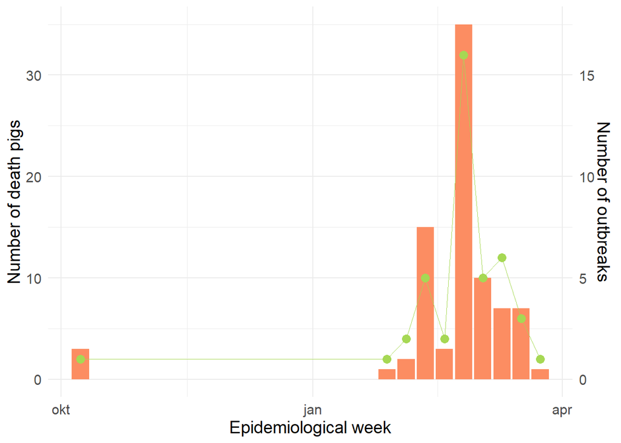

```r
l %>%
  group_by(cases, week=floor_date(Date_first_detection_ill_pig, unit= 'week'))%>%
  filter(cases == "Case") %>%
  # filter(week > "2024-01-01") %>%
  summarise(Cases=sum(l16_N_deaths),
            Outbreaks=sum(cases == 'Case'),
            Observations=n()) %>%
  ggplot()+
  geom_col(aes(week, Cases), fill="#FC8D62")+
  # geom_col(aes(week, Observations), fill="#21918c") +
  geom_point(aes(week, Outbreaks*2), size=3, color="#A6D854")+
  geom_line(aes(week, Outbreaks*2), size=0.1, color="#A6D854")+
  scale_y_continuous(
  sec.axis = sec_axis(trans = ~. /2, name="Number of outbreaks")) +
  labs(fill="",
       x="Epidemiological week",
       y="Number of death pigs")+
  theme_minimal()+
  theme(text = element_text(size = 14)) +
  scale_color_brewer(palette = "Set2")
```

```r
# brewer.pal(n = 4, name = "Set1")
```

## 5.1 Deleting cases

```r
l <- l[l$l2_Way_point != "66",]
l <- l[l$l2_Way_point != "67",]
l <- l[l$l2_Way_point != "116",]
```

```r
l %>%
  filter(dif_first_detection_to_interview >0) %>%
  summarise(n(), mean(dif_first_detection_to_interview))
```

```
## # A tibble: 1 × 2
##   `n()` `mean(dif_first_detection_to_interview)`
##   <int> <drtn>
## 1    47 27.38298 days
```

```r
l %>%
  group_by(l4_Sub_village) %>%
  filter(dif_first_detection_to_interview >0) %>%
  summarise(n(), interval=mean(dif_first_detection_to_interview)) %>%
  arrange(desc(interval))
```

```
## # A tibble: 10 × 3
##    l4_Sub_village `n()` interval
##    <chr>          <int> <drtn>
##  1 Bargonja B         2 97.50000 days
##  2 Lutuk B            9 33.22222 days
##  3 Aeoka A            1 26.00000 days
##  4 Gogo               2 25.50000 days
##  5 Lutuk A           13 23.23077 days
##  6 Aeoka B            7 23.00000 days
##  7 Obaka oo           3 22.00000 days
##  8 Ayeka Yeka         6 20.00000 days
##  9 Kamcoo             1 19.00000 days
## 10 Aeoka C            3 16.00000 days
```

# 6 Fixing grouped variables

```r
l$l14_N_init <- as.numeric(l$l14_N_init)
l$l15_N_affected <- as.numeric(l$l15_N_affected)
l$l16_N_deaths <- as.numeric(l$l16_N_deaths)
l$l17_N_interview <- as.numeric(l$l17_N_interview)

#pigs not death
l$l18_pnd_slaughtered <- gsub("No", "0", l$l18_pnd_slaughtered)
l$l18_pnd_slaughtered <- as.numeric(l$l18_pnd_slaughtered)
l$l19_pnd_sold_alive <- gsub("No", "0", l$l19_pnd_sold_alive)
l$l19_pnd_sold_alive <- as.numeric(l$l19_pnd_sold_alive)
l$l20_pnd_kept <- as.numeric(l$l20_pnd_kept)
l$l19_pnd_sold_alive <- as.numeric(l$l21_pnd_other)
```

# 7 Population check

i.e. Owor Gedge at the start of the outbreak had 20 pigs, no deaths but kept 2, maybe he kept 20 instead of 2. The balance is 18. 20-2=18 Apiyo Grace at the start of the outbreak had 1 pig, no deaths, he kept 10, maybe he kept 1 instead of 10. Balance is -9. 1-10=-9.

```r
datatable(l %>%
  # group_by(l4_Sub_village) %>%
  group_by(l2_Way_point) %>%
  summarise(n(),Initial_pop=sum(l14_N_init, na.rm = TRUE),
            Deaths=sum(l16_N_deaths, na.rm = TRUE),
            # Affected=sum(l15_N_affected, na.rm = TRUE),
            Not_dead=sum(l18_pnd_slaughtered,
                         l19_pnd_sold_alive,
                         l20_pnd_kept, na.rm = TRUE),
            Balance=Initial_pop-Deaths-Not_dead,
            # start=Initial_pop - Now,
    slaughther=sum(l18_pnd_slaughtered, na.rm = TRUE),
            Sold=sum(l19_pnd_sold_alive, na.rm = TRUE),
            Kept=sum(l20_pnd_kept, na.rm = TRUE),
            # Interview=sum(l17_N_interview, na.rm = TRUE),
) %>%
  arrange(desc(Balance)) %>%
  filter(Balance == 0) %>%
  print(n=100))
```

```
## # A tibble: 81 × 9
##    l2_Way_point `n()` Initial_pop Deaths Not_dead Balance slaughther  Sold  Kept
##    <chr>        <int>       <dbl>  <dbl>    <dbl>   <dbl>      <dbl> <dbl> <dbl>
##  1 100              1           9      0        9       0          0     0     9
##  2 101              1           6      0        6       0          0     0     6
##  3 102              1           2      0        2       0          0     0     2
##  4 103              1           4      0        4       0          0     0     4
##  5 104              1           9      0        9       0          0     0     9
##  6 105              1           3      0        3       0          0     0     3
##  7 106              1          10      1        9       0          0     0     9
##  8 108              1           6      0        6       0          0     0     6
##  9 109              1           8      0        8       0          0     0     8
## 10 110              1          21      0       21       0          0     0    21
## 11 111              1           9      0        9       0          0     0     9
## 12 112              1           3      0        3       0          0     0     3
```

[output cut: 69 more lines]

|  | l2_Way_point | n() | Initial_pop | Deaths | Not_dead | Balance | slaughther | Sold | Kept |
| --- | --- | --- | --- | --- | --- | --- | --- | --- | --- |
| 1 | 100 | 1 | 9 | 0 | 9 | 0 | 0 | 0 | 9 |
| 2 | 101 | 1 | 6 | 0 | 6 | 0 | 0 | 0 | 6 |
| 3 | 102 | 1 | 2 | 0 | 2 | 0 | 0 | 0 | 2 |
| 4 | 103 | 1 | 4 | 0 | 4 | 0 | 0 | 0 | 4 |
| 5 | 104 | 1 | 9 | 0 | 9 | 0 | 0 | 0 | 9 |
| 6 | 105 | 1 | 3 | 0 | 3 | 0 | 0 | 0 | 3 |
| 7 | 106 | 1 | 10 | 1 | 9 | 0 | 0 | 0 | 9 |
| 8 | 108 | 1 | 6 | 0 | 6 | 0 | 0 | 0 | 6 |
| 9 | 109 | 1 | 8 | 0 | 8 | 0 | 0 | 0 | 8 |
| 10 | 110 | 1 | 21 | 0 | 21 | 0 | 0 | 0 | 21 |

[output cut: 71 more lines]

## 7.3 Balance check grouped by village.

```r
datatable(l %>%
  group_by(l4_Sub_village) %>%
  # group_by(l6_Name_producer) %>%
  summarise(n(),Initial_pop=sum(l14_N_init, na.rm = TRUE),
            Deaths=sum(l16_N_deaths, na.rm = TRUE),
            # Affected=sum(l15_N_affected, na.rm = TRUE),
            Not_dead=sum(l18_pnd_slaughtered,
                         l19_pnd_sold_alive,
                         l20_pnd_kept, na.rm = TRUE),
            Balance=Initial_pop-Deaths-Not_dead,
            # start=Initial_pop - Now,
    slaughther=sum(l18_pnd_slaughtered, na.rm = TRUE),
            Sold=sum(l19_pnd_sold_alive, na.rm = TRUE),
            Kept=sum(l20_pnd_kept, na.rm = TRUE),
            # Interview=sum(l17_N_interview, na.rm = TRUE),
) %>%
  arrange(desc(Balance)) %>%
  # filter(Balance == 0) %>%
  print(n=100))
```

```
## # A tibble: 13 × 9
##    l4_Sub_village `n()` Initial_pop Deaths Not_dead Balance slaughther  Sold
##    <chr>          <int>       <dbl>  <dbl>    <dbl>   <dbl>      <dbl> <dbl>
##  1 Lutuk A           20          92     16       48      28          0     0
##  2 Aeoka B           13          93     12       66      15          0     0
##  3 Bargonja B         6          26      5       14       7          0     0
##  4 Gogo               3          16      5        6       5          0     0
##  5 Ayeka Yeka         9          49     17       29       3          0     0
##  6 Bargonja A         2           8      0        6       2          0     0
##  7 Aeoka A            4           8      2        6       0          0     0
##  8 Kamcoo             1          20      0       20       0          0     0
##  9 Lacen Otingo       1           5      0        5       0          0     0
## 10 Lamina Too         1           3      0        3       0          0     0
## 11 Aeoka C           13          95      3       93      -1          1     0
## 12 Lutuk B           15          71     16       56      -1          1     0
## 13 Obaka oo           8          28      6       31      -9          0     0
## # ℹ 1 more variable: Kept <dbl>
```

|  | l4_Sub_village | n() | Initial_pop | Deaths | Not_dead | Balance | slaughther | Sold | Kept |
| --- | --- | --- | --- | --- | --- | --- | --- | --- | --- |
| 1 | Lutuk A | 20 | 92 | 16 | 48 | 28 | 0 | 0 | 48 |
| 2 | Aeoka B | 13 | 93 | 12 | 66 | 15 | 0 | 0 | 66 |
| 3 | Bargonja B | 6 | 26 | 5 | 14 | 7 | 0 | 0 | 14 |
| 4 | Gogo | 3 | 16 | 5 | 6 | 5 | 0 | 0 | 6 |
| 5 | Ayeka Yeka | 9 | 49 | 17 | 29 | 3 | 0 | 0 | 29 |
| 6 | Bargonja A | 2 | 8 | 0 | 6 | 2 | 0 | 0 | 6 |
| 7 | Aeoka A | 4 | 8 | 2 | 6 | 0 | 0 | 0 | 6 |
| 8 | Kamcoo | 1 | 20 | 0 | 20 | 0 | 0 | 0 | 20 |
| 9 | Lacen Otingo | 1 | 5 | 0 | 5 | 0 | 0 | 0 | 5 |
| 10 | Lamina Too | 1 | 3 | 0 | 3 | 0 | 0 | 0 | 3 |

[output cut: 3 more lines]

## 7.4 Calculating aparent prevalence

```r
l$l61_apparent_prevalence <- l$l16_N_deaths/l$l14_N_init
l$l62attack_rate <- l$l16_N_deaths/l$l14_N_init

l %>%
  select(l14_N_init,
         l15_N_affected,
         l16_N_deaths,
         l18_pnd_slaughtered,
         l19_pnd_sold_alive,
         l20_pnd_kept,
         l17_N_interview,
         l61_apparent_prevalence) %>%
  descr()
```

```
##
## ## Basic descriptive statistics
##
##                      var    type                   label  n NA.prc mean   sd
##               l14_N_init numeric              l14_N_init 96   0.00 5.35 4.26
##           l15_N_affected numeric          l15_N_affected 88   8.33 0.99 1.56
##             l16_N_deaths numeric            l16_N_deaths 96   0.00 0.85 1.48
##      l18_pnd_slaughtered numeric     l18_pnd_slaughtered 91   5.21 0.02 0.15
##       l19_pnd_sold_alive numeric      l19_pnd_sold_alive 87   9.38 0.00 0.00
##             l20_pnd_kept numeric            l20_pnd_kept 91   5.21 4.19 3.83
##          l17_N_interview numeric         l17_N_interview 96   0.00 4.43 4.23
##  l61_apparent_prevalence numeric l61_apparent_prevalence 96   0.00 0.18 0.28
##    se  md trimmed     range       iqr skew
##  0.44 4.0    4.71 20 (1-21) 5.0000000 1.65
##  0.17 0.5    0.65   9 (0-9) 1.0000000 2.76
##  0.15 0.0    0.50   7 (0-7) 1.0000000 2.45
##  0.02 0.0    0.00   1 (0-1) 0.0000000 6.63
##  0.00 0.0    0.00   0 (0-0) 0.0000000  NaN
##  0.40 3.0    3.62 21 (0-21) 4.0000000 2.05
##  0.43 3.0    3.77 21 (0-21) 4.2500000 1.94
##  0.03 0.0    0.12   1 (0-1) 0.2708333 1.71
```

```r
summary(l$l61_apparent_prevalence)
```

```
##    Min. 1st Qu.  Median    Mean 3rd Qu.    Max.
##  0.0000  0.0000  0.0000  0.1772  0.2708  1.0000
```

```r
l %>%
  group_by(l4_Sub_village) %>%
  select(l14_N_init,
         l15_N_affected,
         l16_N_deaths,
         l18_pnd_slaughtered,
         l19_pnd_sold_alive,
         l20_pnd_kept,
         l17_N_interview,
         l61_apparent_prevalence) %>%
  descr()
```

```
##
## ## Basic descriptive statistics
##
##
## Grouped by: Aeoka A
##
##                      var    type                   label n NA.prc mean   sd
##               l14_N_init numeric              l14_N_init 4      0 2.00 0.82
##           l15_N_affected numeric          l15_N_affected 3     25 0.00 0.00
##             l16_N_deaths numeric            l16_N_deaths 4      0 0.50 1.00
##      l18_pnd_slaughtered numeric     l18_pnd_slaughtered 3     25 0.00 0.00
##       l19_pnd_sold_alive numeric      l19_pnd_sold_alive 3     25 0.00 0.00
##             l20_pnd_kept numeric            l20_pnd_kept 3     25 2.00 1.00
##          l17_N_interview numeric         l17_N_interview 4      0 1.50 1.29
##  l61_apparent_prevalence numeric l61_apparent_prevalence 4      0 0.25 0.50
##    se  md trimmed   range  iqr skew
##  0.41 2.0    2.00 2 (1-3) 0.50    0
##  0.00 0.0    0.00 0 (0-0) 0.00  NaN
##  0.50 0.0    0.50 2 (0-2) 0.50    2
##  0.00 0.0    0.00 0 (0-0) 0.00  NaN
##  0.00 0.0    0.00 0 (0-0) 0.00  NaN
##  0.58 2.0    2.00 2 (1-3) 1.00    0
##  0.65 1.5    1.50 3 (0-3) 1.50    0
##  0.25 0.0    0.25 1 (0-1) 0.25    2
##
##
## Grouped by: Aeoka B
##
##                      var    type                   label  n NA.prc mean   sd
##               l14_N_init numeric              l14_N_init 13   0.00 7.15 4.56
##           l15_N_affected numeric          l15_N_affected 12   7.69 0.92 1.16
##             l16_N_deaths numeric            l16_N_deaths 13   0.00 0.92 1.50
##      l18_pnd_slaughtered numeric     l18_pnd_slaughtered 13   0.00 0.00 0.00
##       l19_pnd_sold_alive numeric      l19_pnd_sold_alive 13   0.00 0.00 0.00
##             l20_pnd_kept numeric            l20_pnd_kept 13   0.00 5.08 3.28
##          l17_N_interview numeric         l17_N_interview 13   0.00 5.08 3.28
##  l61_apparent_prevalence numeric l61_apparent_prevalence 13   0.00 0.15 0.20
##    se  md trimmed       range  iqr skew
##  1.27 5.0    6.91   13 (2-15) 8.00 0.61
##  0.34 0.5    0.80     3 (0-3) 1.25 1.02
```

[output cut: 233 more lines]

```
##             l16_N_deaths numeric            l16_N_deaths 8      0 0.75 1.75
##      l18_pnd_slaughtered numeric     l18_pnd_slaughtered 8      0 0.00 0.00
##       l19_pnd_sold_alive numeric      l19_pnd_sold_alive 6     25 0.00 0.00
##             l20_pnd_kept numeric            l20_pnd_kept 8      0 3.88 3.00
##          l17_N_interview numeric         l17_N_interview 8      0 3.88 3.00
##  l61_apparent_prevalence numeric l61_apparent_prevalence 8      0 0.10 0.22
##    se  md trimmed         range  iqr skew
##  0.94 3.0    3.50       7 (1-8) 4.25 0.60
##  1.19 0.5    1.50       5 (0-5) 2.00 1.78
##  0.62 0.0    0.75       5 (0-5) 0.25 2.63
##  0.00 0.0    0.00       0 (0-0) 0.00  NaN
##  0.00 0.0    0.00       0 (0-0) 0.00  NaN
##  1.06 3.5    3.88      9 (1-10) 2.75 1.31
##  1.06 3.5    3.88      9 (1-10) 2.75 1.31
##  0.08 0.0    0.10 0.62 (0-0.62) 0.05 2.37
```

# 8 Apparent prevalence by farm

```r
datatable(l %>%
  # group_by(l4_Sub_village) %>%
  group_by(l2_Way_point) %>%
  summarise(n(), Initial_pop=sum(l14_N_init, na.rm = TRUE),
            Deaths=sum(l16_N_deaths, na.rm = TRUE),
            # Affected=sum(l15_N_affected, na.rm = TRUE),
            Apparent_prevalence=round((Deaths/Initial_pop),4)*100) %>%
  arrange(desc(Apparent_prevalence)) %>%
  # filter(Balance == 0) %>%
  print(n=100))
```

```
## # A tibble: 96 × 5
##    l2_Way_point `n()` Initial_pop Deaths Apparent_prevalence
##    <chr>        <int>       <dbl>  <dbl>               <dbl>
##  1 30               1           1      1              100
##  2 31               1           4      4              100
##  3 44               1           7      7              100
##  4 68               1           2      2              100
##  5 95               1           2      2              100
##  6 38               1           8      7               87.5
##  7 62               1           3      2               66.7
##  8 72               1           8      5               62.5
##  9 120              1           4      2               50
## 10 126              1           2      1               50
## 11 35               1           4      2               50
## 12 55               1           2      1               50
```

[output cut: 84 more lines]

|  | l2_Way_point | n() | Initial_pop | Deaths | Apparent_prevalence |
| --- | --- | --- | --- | --- | --- |
| 1 | 30 | 1 | 1 | 1 | 100 |
| 2 | 31 | 1 | 4 | 4 | 100 |
| 3 | 44 | 1 | 7 | 7 | 100 |
| 4 | 68 | 1 | 2 | 2 | 100 |
| 5 | 95 | 1 | 2 | 2 | 100 |
| 6 | 38 | 1 | 8 | 7 | 87.5 |
| 7 | 62 | 1 | 3 | 2 | 66.67 |
| 8 | 72 | 1 | 8 | 5 | 62.5 |
| 9 | 120 | 1 | 4 | 2 | 50 |
| 10 | 126 | 1 | 2 | 1 | 50 |

[output cut: 86 more lines]

```r
table(l$cases)
```

```
##
##    Case Control
##      40      56
```

```r
datatable(l %>%
  # group_by(l4_Sub_village) %>%
  group_by(cases) %>%
  summarise(n(),
            Initial_pop=sum(l14_N_init, na.rm = TRUE),
            Deaths=sum(l16_N_deaths, na.rm = TRUE),
            Apparent_prevalence=round((Deaths/Initial_pop),4)*100) %>%
    arrange(desc(Apparent_prevalence)))
```

|  | cases | n() | Initial_pop | Deaths | Apparent_prevalence |
| --- | --- | --- | --- | --- | --- |
| 1 | Case | 40 | 223 | 82 | 36.77 |
| 2 | Control | 56 | 291 | 0 | 0 |

```r
library(epiR)
epi.prev(l$l16_N_deaths[l$cases == "Case"], l$l14_N_init[l$cases == "Case"], 0.95, 0.95, conf.level = 0.99)
```

```
## $ap
##           est      lower     upper
## 1  100.000000  1.0050336 100.00000
## 2  100.000000 37.6120253 100.00000
## 3   33.333333  6.8215111  77.34931
## 4   10.000000  0.1005034  50.72318
## 5   50.000000 10.5069706  89.49303
## 6   40.000000 12.7930560  75.18403
## 7   25.000000  0.2512584  78.18743
## 8   87.500000 42.4828873  99.87437
## 9   25.000000  0.2512584  78.18743
## 10  33.333333  0.3350112  85.57840
## 11  20.000000  0.2010067  71.82213
## 12  14.285714  0.1435762  61.62933
## 13  20.000000  0.2010067  71.82213
```

[output cut: 70 more lines]

# 9 Total Apparent prevalence by cases and no cases

```r
datatable(l %>%
  # group_by(l4_Sub_village) %>%
  group_by(cases) %>%
  summarise(n(), Initial_pop=sum(l14_N_init, na.rm = TRUE),
            Deaths=sum(l16_N_deaths, na.rm = TRUE),
            interview=sum(l17_N_interview, na.rm = TRUE),
            reduction=Initial_pop-interview,
            percent_red=(1-(interview/Initial_pop))*100,
            Apparent_prevalence=round((Deaths/Initial_pop),4)*100) %>%
  arrange(desc(Apparent_prevalence)) %>%
  # filter(Balance == 0) %>%
  print(n=100))
```

```
## # A tibble: 2 × 8
##   cases   `n()` Initial_pop Deaths interview reduction percent_red
##   <chr>   <int>       <dbl>  <dbl>     <dbl>     <dbl>       <dbl>
## 1 Case       40         223     82       140        83       37.2
## 2 Control    56         291      0       285         6        2.06
## # ℹ 1 more variable: Apparent_prevalence <dbl>
```

|  | cases | n() | Initial_pop | Deaths | interview | reduction | percent_red | Apparent_prevalence |
| --- | --- | --- | --- | --- | --- | --- | --- | --- |
| 1 | Case | 40 | 223 | 82 | 140 | 83 | 37.21973094170403 | 36.77 |
| 2 | Control | 56 | 291 | 0 | 285 | 6 | 2.061855670103097 | 0 |

# 10 Total Apparent prevalence by village

```r
datatable(l %>%
  # group_by(l4_Sub_village) %>%
  group_by(cases, l4_Sub_village) %>%
  summarise(n(), Initial_pop=sum(l14_N_init, na.rm = TRUE),
            Deaths=sum(l16_N_deaths, na.rm = TRUE),
            interview=sum(l17_N_interview, na.rm = TRUE),
            reduction=Initial_pop-interview,
            percent_red=(1-(interview/Initial_pop))*100,
            Apparent_prevalence=round((Deaths/Initial_pop),4)*100) %>%
  arrange(desc(Apparent_prevalence)) %>%
  # filter(Balance == 0) %>%
  print(n=100))
```

```
## # A tibble: 22 × 9
## # Groups:   cases [2]
##    cases l4_Sub_village `n()` Initial_pop Deaths interview reduction percent_red
##    <chr> <chr>          <int>       <dbl>  <dbl>     <dbl>     <dbl>       <dbl>
##  1 Case  Aeoka A            1           2      2         0         2       100
##  2 Case  Ayeka Yeka         6          36     17        16        20        55.6
##  3 Case  Obaka oo           2          13      6         7         6        46.2
##  4 Case  Bargonja B         2          12      5         0        12       100
##  5 Case  Lutuk B            9          42     16        27        15        35.7
##  6 Case  Lutuk A            9          43     16        28        15        34.9
##  7 Case  Gogo               2          14      5        18        -4       -28.6
##  8 Case  Aeoka B            6          42     12        28        14        33.3
##  9 Case  Aeoka C            3          19      3        16         3        15.8
## 10 Cont… Aeoka A            3           6      0         6         0         0
## 11 Cont… Aeoka B            7          51      0        38        13        25.5
## 12 Cont… Aeoka C           10          76      0        76         0         0
## 13 Cont… Ayeka Yeka         3          13      0        13         0         0
## 14 Cont… Bargonja A         2           8      0         6         2        25
## 15 Cont… Bargonja B         4          14      0        14         0         0
## 16 Cont… Gogo               1           2      0         2         0         0
## 17 Cont… Kamcoo             1          20      0        20         0         0
## 18 Cont… Lacen Otingo       1           5      0         5         0         0
## 19 Cont… Lamina Too         1           3      0         3         0         0
## 20 Cont… Lutuk A           11          49      0        49         0         0
## 21 Cont… Lutuk B            6          29      0        29         0         0
## 22 Cont… Obaka oo           6          15      0        24        -9       -60
## # ℹ 1 more variable: Apparent_prevalence <dbl>
```

|  | cases | l4_Sub_village | n() | Initial_pop | Deaths | interview | reduction | percent_red | Apparent_prevalence |
| --- | --- | --- | --- | --- | --- | --- | --- | --- | --- |
| 1 | Case | Aeoka A | 1 | 2 | 2 | 0 | 2 | 100 | 100 |
| 2 | Case | Ayeka Yeka | 6 | 36 | 17 | 16 | 20 | 55.55555555555556 | 47.22 |
| 3 | Case | Obaka oo | 2 | 13 | 6 | 7 | 6 | 46.15384615384615 | 46.15000000000001 |
| 4 | Case | Bargonja B | 2 | 12 | 5 | 0 | 12 | 100 | 41.67 |
| 5 | Case | Lutuk B | 9 | 42 | 16 | 27 | 15 | 35.71428571428571 | 38.1 |
| 6 | Case | Lutuk A | 9 | 43 | 16 | 28 | 15 | 34.88372093023256 | 37.21 |
| 7 | Case | Gogo | 2 | 14 | 5 | 18 | -4 | -28.57142857142858 | 35.70999999999999 |
| 8 | Case | Aeoka B | 6 | 42 | 12 | 28 | 14 | 33.33333333333334 | 28.57 |
| 9 | Case | Aeoka C | 3 | 19 | 3 | 16 | 3 | 15.78947368421053 | 15.79 |
| 10 | Control | Aeoka A | 3 | 6 | 0 | 6 | 0 | 0 | 0 |

[output cut: 12 more lines]

## 10.1 Distribution of initial and final population over villages

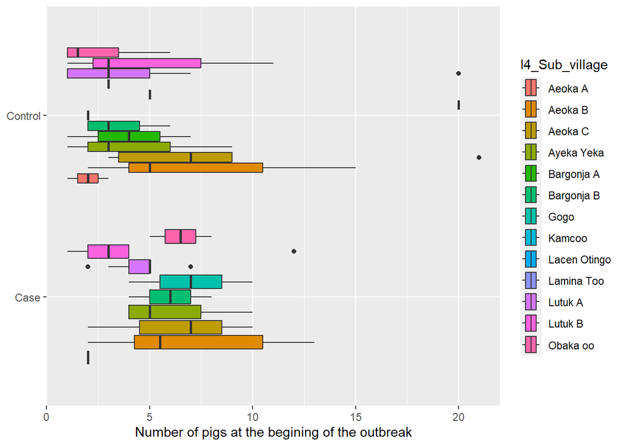

```r
ggplot(l, aes(l14_N_init, cases, fill=l4_Sub_village))+
  geom_boxplot()+
  labs(
    y=NULL,
    x="Number of pigs at the begining of the outbreak"
  )
```

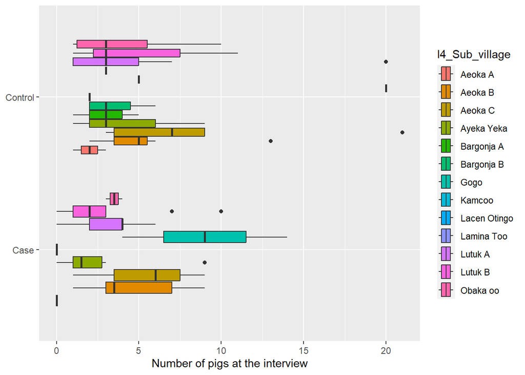

```r
ggplot(l, aes(l17_N_interview, cases, fill=l4_Sub_village))+
  geom_boxplot()+
  labs(
    y=NULL,
    x="Number of pigs at the interview"
  )
```

# 11 Comparison between apparent prevalence

```r
l$ap <- round((l$l16_N_deaths/l$l14_N_init),4)*100

table(l$ap)
```

```
##
##     0  8.33    10 14.29 16.67    20    25 33.33  37.5 38.46    40 41.67    50
##    56     1     2     2     1     6     4     4     1     1     1     1     8
##  62.5 66.67  87.5   100
##     1     1     1     5
```

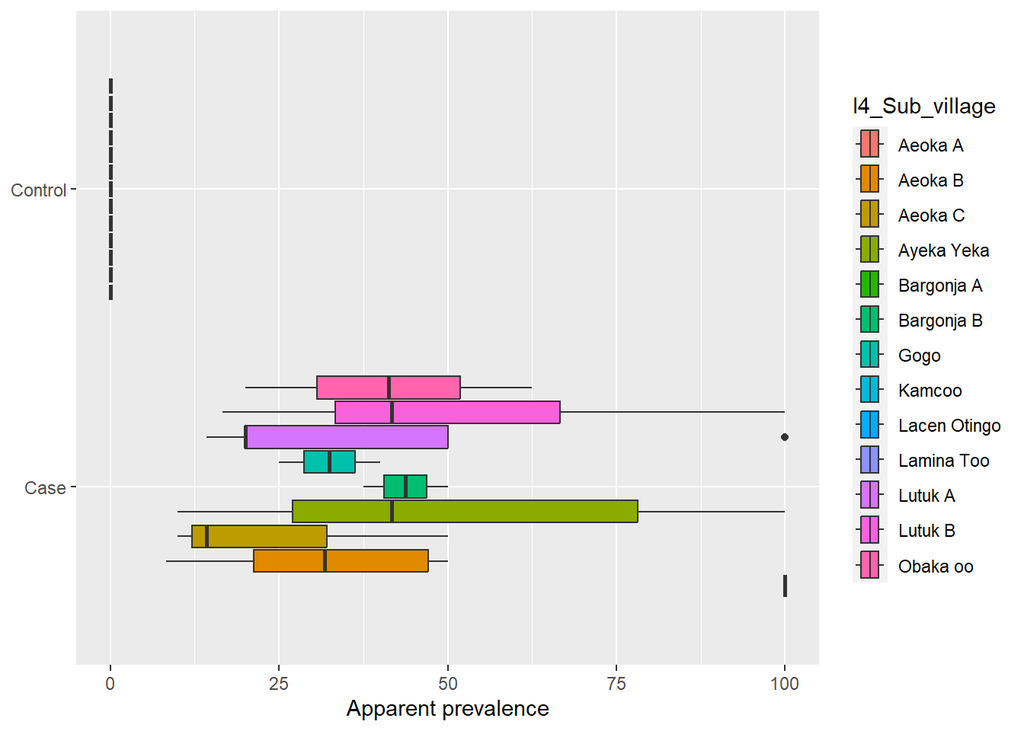

```r
ggplot(l, aes(ap, cases, fill=l4_Sub_village))+
  geom_boxplot()+
  labs(
    y=NULL,
    x="Apparent prevalence"
  )
```

```r
library(forcats)
```

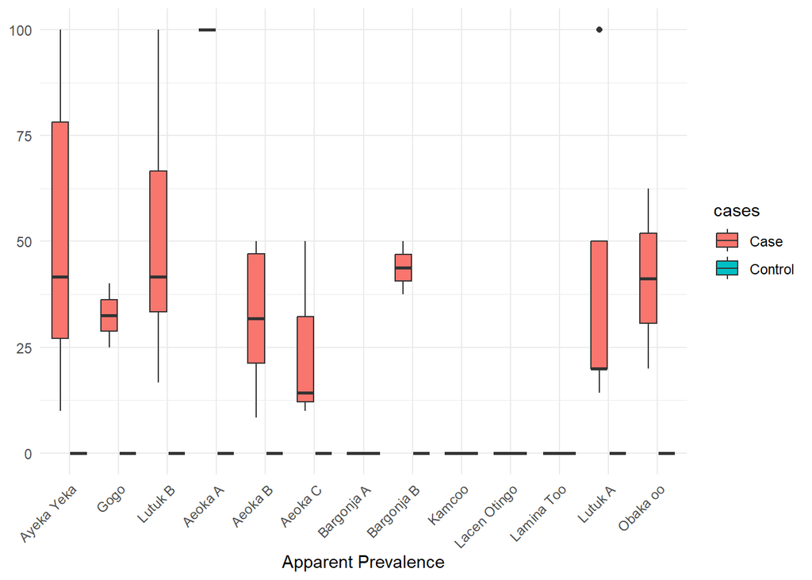

```r
l <- l %>%
  group_by(l4_Sub_village) %>%
  mutate(median_ap = median(ap)) %>%
  ungroup() %>%
  mutate(l4_Sub_village = fct_reorder(l4_Sub_village, median_ap, .desc = TRUE))

# Plot the boxplot
ggplot(l, aes(x = l4_Sub_village, y = ap, fill = cases)) +
  geom_boxplot() +
  labs(
    y = NULL,
    x = "Apparent Prevalence"
  ) +
   theme_minimal() +
  theme(axis.text.x = element_text(angle = 45, hjust = 1))
```

# Comparison between population modification

```r
l$p <- l$l14_N_init - l$l17_N_interview
summary(l$p)
```

```
##     Min.  1st Qu.   Median     Mean  3rd Qu.     Max.
## -10.0000   0.0000   0.0000   0.9271   1.0000  11.0000
```

```r
l$pp <- round((l$l14_N_init+0.001)/l$l17_N_interview,5)*100
summary(l$pp)
```

```
##    Min. 1st Qu.  Median    Mean 3rd Qu.    Max.
##   10.01  100.03  100.10     Inf  150.05     Inf
```

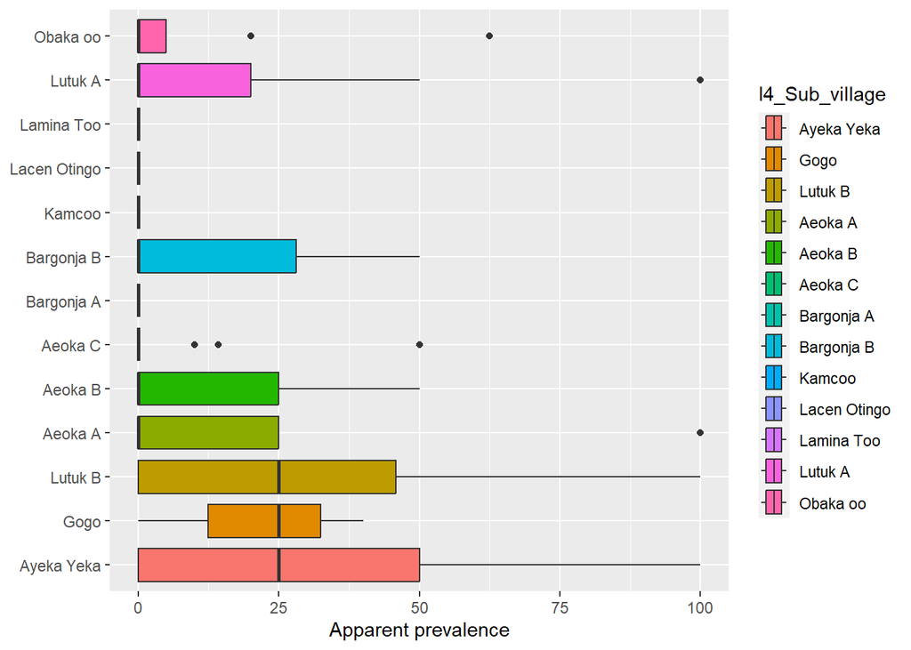

```r
ggplot(l, aes(ap, l4_Sub_village, fill=l4_Sub_village))+
  geom_boxplot()+
  labs(
    y=NULL,
    x="Apparent prevalence"
  )
```

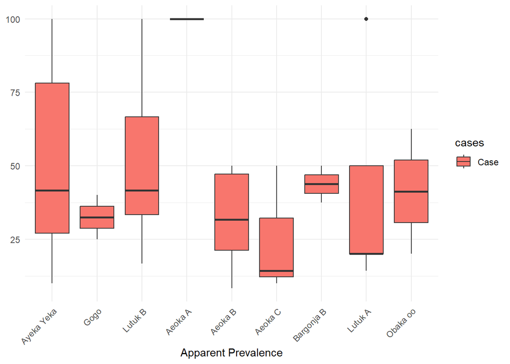

```r
library(forcats)

l <- l %>%
  group_by(l4_Sub_village) %>%
  mutate(median_ap = median(ap)) %>%
  ungroup() %>%
  mutate(l4_Sub_village
         = fct_reorder(l4_Sub_village, median_ap, .desc = TRUE))

# Plot the boxplot
ggplot(data=l[l$cases == "Case",],
       aes(x = l4_Sub_village,
           y = ap,
           fill = cases)) +
  geom_boxplot() +
  labs(
    y = NULL,
    x = "Apparent Prevalence") +
   theme_minimal() +
  theme(axis.text.x = element_text(angle = 45, hjust = 1))
```

# 12 How many pigs did the household have at the start of the outbreak

# 13 What did you do with the pigs that died?

## 13.1 Check errors of problems (nothing wrong found)

```r
l$l23_pd_Ate[l$l23_pd_Ate == "NA"] <- NA
l$l24_pd_Sold[l$l24_pd_Sold == "NA"] <- NA
l$l25_pd_buried[l$l25_pd_buried == "NA"] <- NA
l$l26_pd_burned[l$l26_pd_burned == "NA"] <- NA
l$l27_pd_latrine[l$l27_pd_latrine == "NA"] <- NA
l$l28_pd_bush_swamp_river[l$l28 == "NA"] <- NA
l %>%
  filter(is.na(l23_pd_Ate) & l16_N_deaths != 0)
```

```
## # A tibble: 0 × 73
## # ℹ 73 variables: 1digited_by <chr>, l2_Way_point <chr>, l3_NGwenAna_col <chr>,
## #   l4_Sub_village <fct>, l5_Date_interview <chr>, l6_Name_producer <chr>,
## #   l7_Gender <chr>, l8_Age_years <chr>, l9_Norting <chr>, l10_Easting <chr>,
## #   l11_Interviewed_by_G&Ana <chr>, l12_first_detection_ill_pig <chr>,
## #   l13_first_pig_die <chr>, l14_N_init <dbl>, l15_N_affected <dbl>,
## #   l16_N_deaths <dbl>, l17_N_interview <dbl>, l18_pnd_slaughtered <dbl>,
## #   l19_pnd_sold_alive <dbl>, l20_pnd_kept <dbl>, l21_pnd_other <chr>, …
```

```r
l %>%
  filter(is.na(l24_pd_Sold) & l16_N_deaths != 0)
```

```
## # A tibble: 0 × 73
## # ℹ 73 variables: 1digited_by <chr>, l2_Way_point <chr>, l3_NGwenAna_col <chr>,
## #   l4_Sub_village <fct>, l5_Date_interview <chr>, l6_Name_producer <chr>,
## #   l7_Gender <chr>, l8_Age_years <chr>, l9_Norting <chr>, l10_Easting <chr>,
## #   l11_Interviewed_by_G&Ana <chr>, l12_first_detection_ill_pig <chr>,
## #   l13_first_pig_die <chr>, l14_N_init <dbl>, l15_N_affected <dbl>,
## #   l16_N_deaths <dbl>, l17_N_interview <dbl>, l18_pnd_slaughtered <dbl>,
## #   l19_pnd_sold_alive <dbl>, l20_pnd_kept <dbl>, l21_pnd_other <chr>, …
```

```r
l %>%
  filter(is.na(l25_pd_buried) & l16_N_deaths != 0)
```

```
## # A tibble: 0 × 73
## # ℹ 73 variables: 1digited_by <chr>, l2_Way_point <chr>, l3_NGwenAna_col <chr>,
## #   l4_Sub_village <fct>, l5_Date_interview <chr>, l6_Name_producer <chr>,
## #   l7_Gender <chr>, l8_Age_years <chr>, l9_Norting <chr>, l10_Easting <chr>,
## #   l11_Interviewed_by_G&Ana <chr>, l12_first_detection_ill_pig <chr>,
## #   l13_first_pig_die <chr>, l14_N_init <dbl>, l15_N_affected <dbl>,
## #   l16_N_deaths <dbl>, l17_N_interview <dbl>, l18_pnd_slaughtered <dbl>,
## #   l19_pnd_sold_alive <dbl>, l20_pnd_kept <dbl>, l21_pnd_other <chr>, …
```

```r
l %>%
  filter(is.na(l26_pd_burned) & l16_N_deaths != 0)
```

```
## # A tibble: 0 × 73
## # ℹ 73 variables: 1digited_by <chr>, l2_Way_point <chr>, l3_NGwenAna_col <chr>,
## #   l4_Sub_village <fct>, l5_Date_interview <chr>, l6_Name_producer <chr>,
## #   l7_Gender <chr>, l8_Age_years <chr>, l9_Norting <chr>, l10_Easting <chr>,
## #   l11_Interviewed_by_G&Ana <chr>, l12_first_detection_ill_pig <chr>,
## #   l13_first_pig_die <chr>, l14_N_init <dbl>, l15_N_affected <dbl>,
## #   l16_N_deaths <dbl>, l17_N_interview <dbl>, l18_pnd_slaughtered <dbl>,
## #   l19_pnd_sold_alive <dbl>, l20_pnd_kept <dbl>, l21_pnd_other <chr>, …
```

```r
l %>%
  filter(is.na(l27_pd_latrine) & l16_N_deaths != 0)
```

```
## # A tibble: 0 × 73
## # ℹ 73 variables: 1digited_by <chr>, l2_Way_point <chr>, l3_NGwenAna_col <chr>,
## #   l4_Sub_village <fct>, l5_Date_interview <chr>, l6_Name_producer <chr>,
## #   l7_Gender <chr>, l8_Age_years <chr>, l9_Norting <chr>, l10_Easting <chr>,
## #   l11_Interviewed_by_G&Ana <chr>, l12_first_detection_ill_pig <chr>,
## #   l13_first_pig_die <chr>, l14_N_init <dbl>, l15_N_affected <dbl>,
## #   l16_N_deaths <dbl>, l17_N_interview <dbl>, l18_pnd_slaughtered <dbl>,
## #   l19_pnd_sold_alive <dbl>, l20_pnd_kept <dbl>, l21_pnd_other <chr>, …
```

## 13.2 Changing to numerical to quantify

```r
l$pd_ate <- l$l23_pd_Ate
l$pd_ate <- gsub("Yes", "1", l$pd_ate)
l$pd_ate <- gsub("No", "0", l$pd_ate)

l$pd_sold <- l$l24_pd_Sold
l$pd_sold <- gsub("Yes", "1", l$pd_sold)
l$pd_sold <- gsub("No", "0", l$pd_sold)

l$pd_buried <- l$l25_pd_buried
l$pd_buried <- gsub("Yes", "1", l$pd_buried)
l$pd_buried <- gsub("No", "0", l$pd_buried)

l$pd_burned <- l$l26_pd_burned
l$pd_burned <- gsub("Yes", "1", l$pd_burned)
l$pd_burned <- gsub("No", "0", l$pd_burned)

l$pd_latrine <- l$l27_pd_latrine
l$pd_latrine <- gsub("Yes", "1", l$pd_latrine)
l$pd_latrine <- gsub("No", "0", l$pd_latrine)

l$pd_bush_river <- l$l28_pd_bush_swamp_river
l$pd_bush_river <- gsub("Yes", "1", l$pd_bush_river)
l$pd_bush_river <- gsub("No", "0", l$pd_bush_river)

l$pd_other <- l$l29_pd_other
l$pd_other <- gsub("Yes", "1", l$pd_other)
l$pd_other <- gsub("No", "0", l$pd_other)

l$pd_ate <- as.numeric(l$pd_ate)
l$pd_sold <- as.numeric(l$pd_sold)
l$pd_buried <- as.numeric(l$pd_buried)
l$pd_burned <- as.numeric(l$pd_burned)
l$pd_latrine <- as.numeric(l$pd_latrine)
l$pd_bush_river <- as.numeric(l$pd_bush_river)
l$pd_other <- as.numeric(l$pd_ate)
```

```r
actions_sick <- data.frame(t(l %>%
  group_by(cases) %>%
  summarise(
            Ate=sum(pd_ate, na.rm =TRUE),
            Sold=sum(pd_sold, na.rm =TRUE),
            Burried=sum(pd_buried, na.rm =TRUE),
            Burned=sum(pd_burned, na.rm =TRUE),
            Latrine=sum(pd_latrine, na.rm =TRUE),
            Bush=sum(pd_bush_river, na.rm =TRUE),
            Other=sum(pd_other, na.rm =TRUE),)))

actions_sick$resposes <- as.numeric(actions_sick$X2)/40
datatable(actions_sick)
```

|  | X1 | X2 | resposes |
| --- | --- | --- | --- |
| cases | Case | Control |  |
| Ate | 19 | 0 | 0 |
| Sold | 25 | 0 | 0 |
| Burried | 0 | 0 | 0 |
| Burned | 1 | 0 | 0 |
| Latrine | 2 | 0 | 0 |
| Bush | 5 | 0 | 0 |
| Other | 19 | 0 | 0 |

```r
l %>%
  group_by(l$l4_Sub_village) %>%
  summarise(Ate=sum(pd_ate, na.rm =TRUE),
            Sold=sum(pd_sold, na.rm =TRUE),
            Burried=sum(pd_buried, na.rm =TRUE),
            Burned=sum(pd_burned, na.rm =TRUE),
            Latrine=sum(pd_latrine, na.rm =TRUE),
            Bush=sum(pd_bush_river, na.rm =TRUE),
            Other=sum(pd_other, na.rm =TRUE),)
```

```
## # A tibble: 13 × 8
##    `l$l4_Sub_village`   Ate  Sold Burried Burned Latrine  Bush Other
##    <fct>              <dbl> <dbl>   <dbl>  <dbl>   <dbl> <dbl> <dbl>
##  1 Ayeka Yeka             3     5       0      0       0     0     3
##  2 Gogo                   1     0       0      0       0     0     1
##  3 Lutuk B                3     4       0      1       1     2     3
##  4 Aeoka A                0     1       0      0       0     0     0
##  5 Aeoka B                4     5       0      0       1     0     4
##  6 Aeoka C                2     2       0      0       0     0     2
##  7 Bargonja A             0     0       0      0       0     0     0
##  8 Bargonja B             2     2       0      0       0     0     2
##  9 Kamcoo                 0     0       0      0       0     0     0
## 10 Lacen Otingo           0     0       0      0       0     0     0
## 11 Lamina Too             0     0       0      0       0     0     0
## 12 Lutuk A                3     5       0      0       0     2     3
## 13 Obaka oo               1     1       0      0       0     1     1
```

```r
l <- l %>%
  mutate(individual_what_did_sick_pigs=sum(pd_ate,
                                           pd_sold,
                                           pd_buried,
                                           pd_burned,
                                           pd_latrine,
                                           pd_bush_river,
                                           pd_other, na.rm = TRUE))

table(l$individual_what_did_sick_pigs)
```

```
##
## 71
## 96
```

```r
table(l$cases)
```

```
##
##    Case Control
##      40      56
```

# 14 Map

## 14.1 Checking coordinates

Preparing coordinates

## 14.2 ? 31 Check Acayo Nighthy Santo nort coordinate (y), it is the same as x. Correct.

```r
l$y <- l$l9_Norting
l$y <- gsub("-", ".", l$y)
l$y <- as.numeric(l$y)

l$x <- l$l10_Easting
l$x <- gsub("-", ".", l$x)
l$x <- as.numeric(l$x)

#? coordinates
l$y[l$l2_Way_point == "31"] <- "2.57189"
l$x[l$l2_Way_point == "56"] <- "32.061810"

# plot(l$x, l$y)
```

## 14.4 Manipulable map of the complete dataset

```r
library(leaflet)
library(stringr)
s <- "Alfredo Acosta"
paste(substr(word(s, 1), 1,3), substr(word(s, 2), 1,3))
```

```
## [1] "Alf Aco"
```

```r
l$owner <- paste(substr(word(l$l6_Name_producer, 1), 1,3), substr(word(l$l6_Name_producer, 2), 1,2))
l$id <- l$l2_Way_point
l$village <- l$l4_Sub_village
l$x <- as.numeric(l$x)
l$y <- as.numeric(l$y)

map <- leaflet(l) %>%
  addProviderTiles(providers$Esri.WorldImagery)

# palete for case and control
pal <- colorFactor(c("red", "blue"), domain=c("Case", "Control"))

mc <- map %>%
  setView(lng = 32, lat = 2, zoom = 7) %>%
  addCircleMarkers(~x, ~y,
            stroke = FALSE, fillOpacity = 0.4,
             color = ~pal(cases),
             popup = ~paste("ID:", id,
                            "<br>", "Owner:", owner,
                             "<br>", "Prevalence", ap,
                             "<br>", "Deaths", l16_N_deaths))
```

```r
library(viridis)
library(leafsync)
```

```r
map <- leaflet(l) %>%
  addProviderTiles(providers$OpenStreetMap.Mapnik)

# palete for case and control
pal <- colorFactor(viridis_pal(option = "D")(length(unique(l$l4_Sub_village))),
                   domain=unique(l$l4_Sub_village))

mv <- map %>%
  setView(lng = 32, lat = 2, zoom = 7) %>%
  addCircleMarkers(~x, ~y,
            stroke = FALSE, fillOpacity = 1,
             color = ~pal(l4_Sub_village),
             popup = ~paste("Village", l4_Sub_village,
                            "<br>","ID:", id,
                            # "<br>", "Owner:", owner,
                             "<br>", "Gender", l7_Gender,
                             "<br>", "pigs_interv", l17_N_interview)) %>%
    addLegend(pal = pal,
            values = ~l4_Sub_village,
    position = "bottomleft")
```

# 15 Combinaed map cases and villages

```r
leafsync::sync(mc,mv)
```

[interactive chart not shown]

## 15.1 pub map Lutuk

```r
library(ggmap)
# lu <- get_stadiamap(bbox = c(left = 31,
#                                bottom = 2,
#                                right = 32,
#                                top = 3),
#                       zoom = 8,
#                       arg = "terrain-background")
```

# 16 Spatial temporal analysis

## 16.1 Preparing satscan files

```r
# pop
# DPA_parr, amount, fecha
#
# cases
# DPA_parroq, amount, date
#
# geo
# DPA_parroq, lon, lat


pop <- l %>%
  select(l2_Way_point, l14_N_init, Date_first_detection_ill_pig) %>%
  mutate(Date_first_detection_ill_pig_completed=ifelse(is.na(Date_first_detection_ill_pig), as.Date("2024-01-01"), Date_first_detection_ill_pig)) %>%
  group_by(l2_Way_point, l14_N_init, Date_first_detection_ill_pig, Date_first_detection_ill_pig_completed)

pop$Date_first_detection_ill_pig_completed <- as.Date(pop$Date_first_detection_ill_pig_completed)

# First run with cases of october
cases <- l %>%
  filter(cases == "Case") %>%
  filter(!is.na(Date_first_detection_ill_pig)) %>%
  select(l2_Way_point, l16_N_deaths, Date_first_detection_ill_pig) %>%
  group_by(l2_Way_point, l16_N_deaths, Date_first_detection_ill_pig)

#second run with the cases since 2024-01-01
cases <- l %>%
  filter(cases == "Case") %>%
  filter(year(Date_first_detection_ill_pig) == "2024") %>%
  filter(!is.na(Date_first_detection_ill_pig)) %>%
  select(l2_Way_point, l16_N_deaths, Date_first_detection_ill_pig) %>%
  group_by(l2_Way_point, l16_N_deaths, Date_first_detection_ill_pig)


geo <- l %>%
  select(l2_Way_point, y, x) %>%
  group_by(l2_Way_point, y, x)

# write.csv(pop, file = "pop.csv")
# write.csv(cases, file = "cases.csv")
# write.csv(geo, file = "geo.csv")
```

# 17 Credits

Acosta, Alfredo PhD<sup>1</sup>. **SVA<sup>1</sup>**: SVA http://www.sva.se/.